# Artificial Intelligence : Computer Assignment 4 - Machine Learning Introduction

> **Morteza Nouri, 810198481**

## Goals:

- An Introduction to Machine Learning methods.
- Working with Scikit-Learn library.

## Description:

> In this project we are going to work on a dataset which gathered by spotify which contains information about musics inclouding artist name, genre and etc. We aim to use some supervised learning algorithms to predict the genre of music.

## Phase 0: Exploratory Data Analysis and Visualization

The first step in any machine learning project is to observe, recognize and analyze data and the relationship between them.

**Q 0.1**:

```python
import pandas

original_df = pandas.read_csv("dataset.csv")

original_df
```

|  | artist_name | track_name | popularity | acousticness | danceability | duration_ms | energy | instrumentalness | key | liveness | loudness | mode | speechiness | tempo | valence | music_genre |
| --- | --- | --- | --- | --- | --- | --- | --- | --- | --- | --- | --- | --- | --- | --- | --- | --- |
| 0 | Blockhead | Cheer up, You're Not Dead Yet | 44.0 | 0.00621 | 0.711 | 285987.0 | 0.6210 | 0.029700 | G | 0.1590 | -7.429 | Major | 0.0382 | 142.065 | 0.6070 | Jazz |
| 1 | FloFilz | Corners | 34.0 | 0.34700 | 0.729 | 103703.0 | 0.5150 | 0.006920 | C | 0.1270 | -10.147 | Major | 0.1840 | 79.969 | 0.2870 | Jazz |
| 2 | Bonobo | We Could Forever | 51.0 | 0.01810 | 0.669 | NaN | 0.8850 | 0.880000 | G | 0.2650 | -7.080 | Minor | 0.0378 | NaN | 0.6360 | Jazz |
| 3 | Nils Landgren | A Child Is Born | 39.0 | 0.91800 | 0.484 | 228733.0 | 0.0693 | 0.000069 | F | 0.1390 | -15.542 | Major | 0.0346 | 82.707 | 0.2060 | Jazz |
| 4 | Masayoshi Takanaka | Samba Pati | 36.0 | 0.03450 | 0.473 | 342867.0 | 0.8230 | 0.446000 | G | 0.3060 | -6.625 | Major | 0.0630 | 104.694 | 0.3830 | Jazz |
| ... | ... | ... | ... | ... | ... | ... | ... | ... | ... | ... | ... | ... | ... | ... | ... | ... |
| 29995 | Wolfgang Amadeus Mozart | Die Zauberflöte, K. 620: Wie stark ist nicht d... | 22.0 | 0.91100 | 0.326 | 368640.0 | 0.1330 | 0.000000 | G | 0.1300 | -20.493 | Major | 0.0557 | 92.090 | 0.2060 | Classical |
| 29996 | New York Philharmonic | Symphony No. 2 in D Major, Op. 73: II. Adagio ... | 26.0 | 0.96500 | 0.126 | 514213.0 | 0.2040 | 0.869000 | B | 0.1060 | -16.474 | Major | 0.0395 | 82.437 | 0.0387 | Classical |
| 29997 | Georges Bizet | Bizet: Carmen, WD 31, Act 1 Scene 4: No. 5, Ha... | 54.0 | 0.97600 | 0.363 | 262147.0 | 0.1150 | 0.000000 | D | 0.0992 | -17.325 | Major | 0.0689 | NaN | 0.2310 | Classical |
| 29998 | Edvard Grieg | Peer Gynt-Suite Nr. 1, Op. 46: I. Morning | 42.0 | 0.98500 | 0.123 | 259573.0 | 0.0174 | 0.906000 | E | 0.1250 | -23.671 | Major | 0.0408 | 71.705 | 0.0352 | Classical |
| 29999 | Johann Sebastian Bach | Suite No. 2 in B Minor, BWV 1067: VI. Menuet | 36.0 | 0.77200 | 0.486 | 74600.0 | 0.1570 | 0.906000 | G# | 0.1470 | -19.078 | Minor | 0.0375 | 124.737 | 0.6190 | Classical |

30000 rows × 16 columns

```python
original_df.info()
```

```
<class 'pandas.core.frame.DataFrame'>
RangeIndex: 30000 entries, 0 to 29999
Data columns (total 16 columns):
 #   Column            Non-Null Count  Dtype
---  ------            --------------  -----
 0   artist_name       28506 non-null  object
 1   track_name        30000 non-null  object
 2   popularity        30000 non-null  float64
 3   acousticness      30000 non-null  float64
 4   danceability      30000 non-null  float64
 5   duration_ms       26990 non-null  float64
 6   energy            30000 non-null  float64
 7   instrumentalness  30000 non-null  float64
 8   key               30000 non-null  object
 9   liveness          30000 non-null  float64
 10  loudness          30000 non-null  float64
 11  mode              30000 non-null  object
 12  speechiness       30000 non-null  float64
 13  tempo             27067 non-null  float64
 14  valence           30000 non-null  float64
 15  music_genre       30000 non-null  object
dtypes: float64(11), object(5)
memory usage: 3.7+ MB
```

```python
original_df.describe(include="all")
```

|  | artist_name | track_name | popularity | acousticness | danceability | duration_ms | energy | instrumentalness | key | liveness | loudness | mode | speechiness | tempo | valence | music_genre |
| --- | --- | --- | --- | --- | --- | --- | --- | --- | --- | --- | --- | --- | --- | --- | --- | --- |
| count | 28506 | 30000 | 30000.000000 | 30000.000000 | 30000.000000 | 2.699000e+04 | 30000.000000 | 30000.000000 | 30000 | 30000.000000 | 30000.000000 | 30000 | 30000.000000 | 27067.000000 | 30000.000000 | 30000 |
| unique | 5090 | 26298 | NaN | NaN | NaN | NaN | NaN | NaN | 12 | NaN | NaN | 2 | NaN | NaN | NaN | 6 |
| top | Wolfgang Amadeus Mozart | Forever | NaN | NaN | NaN | NaN | NaN | NaN | G | NaN | NaN | Major | NaN | NaN | NaN | Jazz |
| freq | 402 | 11 | NaN | NaN | NaN | NaN | NaN | NaN | 3441 | NaN | NaN | 19966 | NaN | NaN | NaN | 5000 |
| mean | NaN | NaN | 47.769533 | 0.359661 | 0.540929 | 2.466460e+05 | 0.556709 | 0.180807 | NaN | 0.183610 | -10.079862 | NaN | 0.083861 | 117.559824 | 0.446563 | NaN |
| std | NaN | NaN | 14.512665 | 0.364182 | 0.181719 | 1.126005e+05 | 0.277856 | 0.329365 | NaN | 0.150733 | 6.953936 | NaN | 0.093366 | 30.719934 | 0.248745 | NaN |
| min | NaN | NaN | 0.000000 | 0.000001 | 0.059600 | 1.550900e+04 | 0.000792 | 0.000000 | NaN | 0.015700 | -47.046000 | NaN | 0.022300 | 34.347000 | 0.000000 | NaN |
| 25% | NaN | NaN | 39.000000 | 0.029600 | 0.423000 | 1.904930e+05 | 0.361000 | 0.000000 | NaN | 0.095800 | -12.057250 | NaN | 0.035000 | 92.340000 | 0.243000 | NaN |
| 50% | NaN | NaN | 49.000000 | 0.205000 | 0.553000 | 2.245600e+05 | 0.602000 | 0.000089 | NaN | 0.122000 | -7.623000 | NaN | 0.045100 | 115.491000 | 0.435000 | NaN |
| 75% | NaN | NaN | 57.000000 | 0.710000 | 0.671000 | 2.726670e+05 | 0.786000 | 0.125250 | NaN | 0.222000 | -5.429750 | NaN | 0.080300 | 139.817500 | 0.639000 | NaN |
| max | NaN | NaN | 99.000000 | 0.996000 | 0.977000 | 3.195440e+06 | 0.998000 | 0.994000 | NaN | 0.996000 | 1.342000 | NaN | 0.941000 | 219.331000 | 0.985000 | NaN |

**Q 0.2:**  
As we can observe, artist_name, duration_ms and tempo columns has lost values.

```python
(1 - (original_df.count() / len(original_df))) * 100
```

```
artist_name          4.980000
track_name           0.000000
popularity           0.000000
acousticness         0.000000
danceability         0.000000
duration_ms         10.033333
energy               0.000000
instrumentalness     0.000000
key                  0.000000
liveness             0.000000
loudness             0.000000
mode                 0.000000
speechiness          0.000000
tempo                9.776667
valence              0.000000
music_genre          0.000000
dtype: float64
```

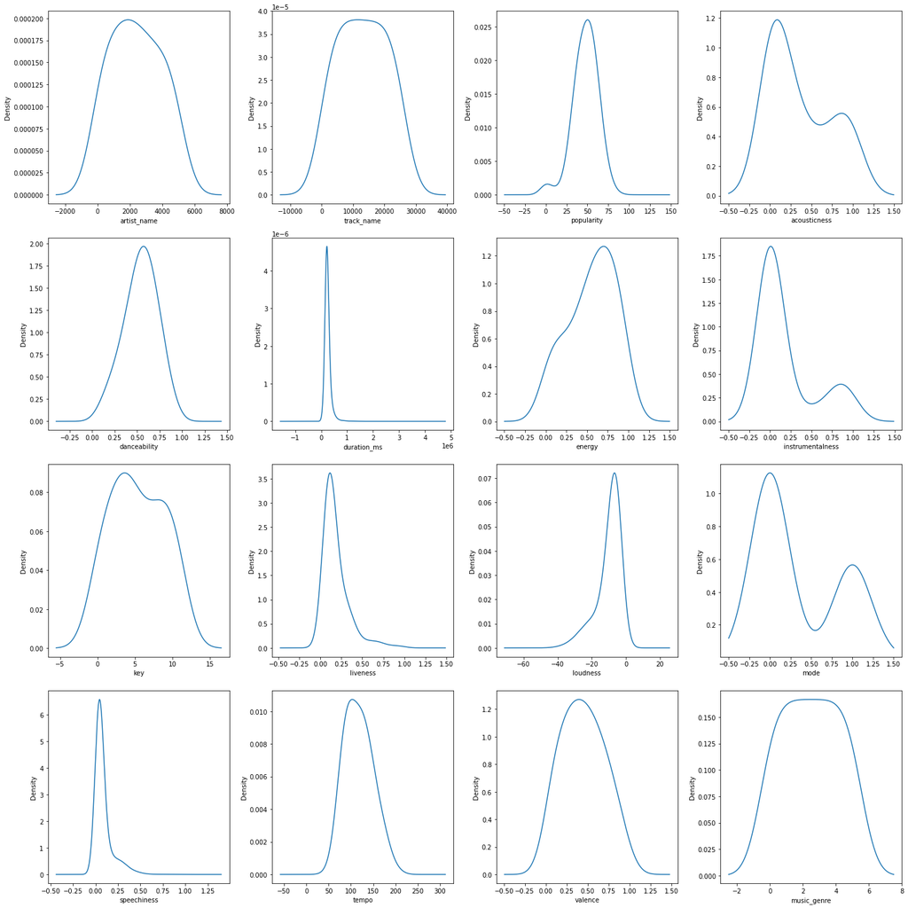

```python
import matplotlib.pyplot as plt
plt.figure(figsize=(20,20))
i = 0
columns = original_df.columns.tolist()
for col in columns:
    plt.subplot(4, 4, i + 1)
    if original_df[col].dtypes != 'object':
        original_df[col].plot.kde(bw_method=0.5).set_xlabel(col)
    else:
        original_df[col].astype('category').cat.codes.plot.kde(bw_method=0.5).set_xlabel(col)
    i += 1

plt.tight_layout()
plt.show()
```

## Part 1: Preprocessing

**Q 1.1:**

There are many mehtod to deal with missing data:

- **Delete rows with missing data :** This method is the easiest way to deal with missing problem. A model trained with the removal of all missing data creates a robust and highly accurate model. Deleting a particular row or a column with no specific information is better, since it does not have a high weightage. On the other hand we lose a lot of information and in our case which lost data is around 24%, losing this amount of data will damage our dataset.
- **Replacing with Mean, Median, or Mode :** Replacing with mean and median method can apply on numerical values like human age. Replacing with mode is good approach for non-numerical values such as strings. This is a better approach when the data size is small but imputing the approximations add variance and bias which in our data is very high.
- **Regression Imputation:** This approach replaces missing values with a predicted value based on a regression line. Regression is a statistical method which shows the relationship between a dependent variable and independent variables. It's expressed as y = mx + b where m is the slope, b is a constant, x is the independent variable and y is the dependent variable.

_I drop rows with missing artist*name.*  
_I replace missing values in duration*ms and tempo columns with mean of each column.*

**Q 1.2:**

```python
clean_df = original_df.copy()
clean_df.dropna(subset=['artist_name'], inplace=True)
clean_df['duration_ms'].fillna(value=clean_df['duration_ms'].mean(), inplace=True)
clean_df['tempo'].fillna(value=clean_df['tempo'].mean(), inplace=True)

(1 - (clean_df.count() / len(clean_df))) * 100
```

```
artist_name         0.0
track_name          0.0
popularity          0.0
acousticness        0.0
danceability        0.0
duration_ms         0.0
energy              0.0
instrumentalness    0.0
key                 0.0
liveness            0.0
loudness            0.0
mode                0.0
speechiness         0.0
tempo               0.0
valence             0.0
music_genre         0.0
dtype: float64
```

**Q 1.3:**

- **Normalization:** a good technique to use when you do not know the distribution of your data or when you know the distribution is not Gaussian (a bell curve). Normalization is useful when your data has varying scales and the algorithm you are using does not make assumptions about the distribution of your data, such as k-nearest neighbors and artificial neural networks.
- **Standardization**: Assumes that your data has a Gaussian (bell curve) distribution. This does not strictly have to be true, but the technique is more effective if your attribute distribution is Gaussian. Standardization is useful when your data has varying scales and the algorithm you are using does make assumptions about your data having a Gaussian distribution, such as linear regression, logistic regression, and linear discriminant analysis.

**Q 1.4:**  
I use Normalization here because some of the numerical distributions in part 0.3 are not in Gaussian form and we want to use k-nearest and decision tree later in this project.

**Q 1.5:**

- **Binary Feature Encoding:** Binary features are those with only two possible values.(e.g. mode in our dataset)
- **Ordinal Feature Encoding:** Ordinal features are those with some order associated with them.(e.g. low, medium, high)
- **Nominal Features Encoding:** Nominal features are categorical features that have no numerical importance. Order does not matter.(e.g. music_genre in our dataset)

*_I use binary encoding for mode column and nominal encoding for key and music*genre columns.*

```python
from sklearn.preprocessing import OneHotEncoder, LabelEncoder
oneHotEncoder = OneHotEncoder()
labelEncoder = LabelEncoder()

ready_df = clean_df.copy()

ready_df['key'] = labelEncoder.fit_transform(ready_df['key'])
ready_df['mode'] = ready_df['mode'].replace({'Major':1, 'Minor':0})

ready_df['music_genre'] = labelEncoder.fit_transform(ready_df['music_genre'])
# genres = oneHotEncoder.fit_transform(ready_df[['music_genre']]).toarray()
# genres = pandas.DataFrame(genres, columns=oneHotEncoder.get_feature_names_out())
# ready_df = pandas.concat([ready_df.reset_index(drop=True), genres.reset_index(drop=True)], axis = 1)

ready_df
```

|  | artist_name | track_name | popularity | acousticness | danceability | duration_ms | energy | instrumentalness | key | liveness | loudness | mode | speechiness | tempo | valence | music_genre |
| --- | --- | --- | --- | --- | --- | --- | --- | --- | --- | --- | --- | --- | --- | --- | --- | --- |
| 0 | Blockhead | Cheer up, You're Not Dead Yet | 44.0 | 0.00621 | 0.711 | 285987.000000 | 0.6210 | 0.029700 | 10 | 0.1590 | -7.429 | 1 | 0.0382 | 142.065000 | 0.6070 | 3 |
| 1 | FloFilz | Corners | 34.0 | 0.34700 | 0.729 | 103703.000000 | 0.5150 | 0.006920 | 3 | 0.1270 | -10.147 | 1 | 0.1840 | 79.969000 | 0.2870 | 3 |
| 2 | Bonobo | We Could Forever | 51.0 | 0.01810 | 0.669 | 246437.479668 | 0.8850 | 0.880000 | 10 | 0.2650 | -7.080 | 0 | 0.0378 | 117.583348 | 0.6360 | 3 |
| 3 | Nils Landgren | A Child Is Born | 39.0 | 0.91800 | 0.484 | 228733.000000 | 0.0693 | 0.000069 | 8 | 0.1390 | -15.542 | 1 | 0.0346 | 82.707000 | 0.2060 | 3 |
| 4 | Masayoshi Takanaka | Samba Pati | 36.0 | 0.03450 | 0.473 | 342867.000000 | 0.8230 | 0.446000 | 10 | 0.3060 | -6.625 | 1 | 0.0630 | 104.694000 | 0.3830 | 3 |
| ... | ... | ... | ... | ... | ... | ... | ... | ... | ... | ... | ... | ... | ... | ... | ... | ... |
| 29995 | Wolfgang Amadeus Mozart | Die Zauberflöte, K. 620: Wie stark ist nicht d... | 22.0 | 0.91100 | 0.326 | 368640.000000 | 0.1330 | 0.000000 | 10 | 0.1300 | -20.493 | 1 | 0.0557 | 92.090000 | 0.2060 | 1 |
| 29996 | New York Philharmonic | Symphony No. 2 in D Major, Op. 73: II. Adagio ... | 26.0 | 0.96500 | 0.126 | 514213.000000 | 0.2040 | 0.869000 | 2 | 0.1060 | -16.474 | 1 | 0.0395 | 82.437000 | 0.0387 | 1 |
| 29997 | Georges Bizet | Bizet: Carmen, WD 31, Act 1 Scene 4: No. 5, Ha... | 54.0 | 0.97600 | 0.363 | 262147.000000 | 0.1150 | 0.000000 | 5 | 0.0992 | -17.325 | 1 | 0.0689 | 117.583348 | 0.2310 | 1 |
| 29998 | Edvard Grieg | Peer Gynt-Suite Nr. 1, Op. 46: I. Morning | 42.0 | 0.98500 | 0.123 | 259573.000000 | 0.0174 | 0.906000 | 7 | 0.1250 | -23.671 | 1 | 0.0408 | 71.705000 | 0.0352 | 1 |
| 29999 | Johann Sebastian Bach | Suite No. 2 in B Minor, BWV 1067: VI. Menuet | 36.0 | 0.77200 | 0.486 | 74600.000000 | 0.1570 | 0.906000 | 11 | 0.1470 | -19.078 | 0 | 0.0375 | 124.737000 | 0.6190 | 1 |

28506 rows × 16 columns

**Q 1.6:**  
There are lots of unique artist_name in our dataset. We cannot use label encoding for this large diversity of names because there is no order between names and coding them confuse our model since we use statistical methods. So we remove this column.

**Q 1.7:**

```python
from sklearn.feature_selection import mutual_info_classif
from sklearn.preprocessing import Normalizer

target = clean_df['music_genre']
X = ready_df.copy()
X = X.drop(['artist_name', 'track_name', 'music_genre'], axis=1)
normalizer = Normalizer()
normalized = normalizer.fit_transform(X)

IG = mutual_info_classif(normalized, target)
IG = pandas.Series(IG)
IG.index = X.columns
IG
```

```
popularity          0.292624
acousticness        0.211907
danceability        0.205280
duration_ms         0.107265
energy              0.290411
instrumentalness    0.271561
key                 0.024359
liveness            0.031797
loudness            0.183804
mode                0.102868
speechiness         0.154257
tempo               0.075499
valence             0.140695
dtype: float64
```

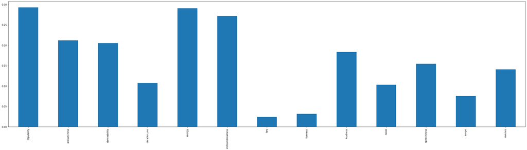

```python
plt.figure(figsize=(40,10))
IG.plot.bar()
plt.show()
```

**Q 1.8:**  
As we can see above, some features like mode, key andlivness have small information gain thus we can ignore them. instead, some features like popularity, energy and instrumentalness have more information gain and we keep these features in our training.  
From a general point of view, more features lead to training a better machine learning model. but it’s not recommended to use all sets of features:

- The real-world data contains a lot of redundant features, that need to remove, in order to train a robust model.
- As the number of features in the data increases, the number of configurations covered by features decreases and the trained model would not generalize to the new samples.
- Model explainability decreases, when the input data has a lot of features, hence making it difficult to interpret the model.

```python
# dropping features with low information gain
key = IG.keys().tolist()
value = IG.values
rm_cols = []
for i in range(len(key)):
    if value[i] < 0.12:
        rm_cols.append(key[i])

final_df = X.drop(rm_cols, axis=1).reset_index(drop=True).copy()
final_df
```

|  | popularity | acousticness | danceability | energy | instrumentalness | loudness | speechiness | valence |
| --- | --- | --- | --- | --- | --- | --- | --- | --- |
| 0 | 44.0 | 0.00621 | 0.711 | 0.6210 | 0.029700 | -7.429 | 0.0382 | 0.6070 |
| 1 | 34.0 | 0.34700 | 0.729 | 0.5150 | 0.006920 | -10.147 | 0.1840 | 0.2870 |
| 2 | 51.0 | 0.01810 | 0.669 | 0.8850 | 0.880000 | -7.080 | 0.0378 | 0.6360 |
| 3 | 39.0 | 0.91800 | 0.484 | 0.0693 | 0.000069 | -15.542 | 0.0346 | 0.2060 |
| 4 | 36.0 | 0.03450 | 0.473 | 0.8230 | 0.446000 | -6.625 | 0.0630 | 0.3830 |
| ... | ... | ... | ... | ... | ... | ... | ... | ... |
| 28501 | 22.0 | 0.91100 | 0.326 | 0.1330 | 0.000000 | -20.493 | 0.0557 | 0.2060 |
| 28502 | 26.0 | 0.96500 | 0.126 | 0.2040 | 0.869000 | -16.474 | 0.0395 | 0.0387 |
| 28503 | 54.0 | 0.97600 | 0.363 | 0.1150 | 0.000000 | -17.325 | 0.0689 | 0.2310 |
| 28504 | 42.0 | 0.98500 | 0.123 | 0.0174 | 0.906000 | -23.671 | 0.0408 | 0.0352 |
| 28505 | 36.0 | 0.77200 | 0.486 | 0.1570 | 0.906000 | -19.078 | 0.0375 | 0.6190 |

28506 rows × 8 columns

## Phase 2: Model Training, Evaluation and Hyper Parameter Tuning

**Q 2.1:**

Data is split as per a split ratio which is highly dependent on the type of model we are building and the dataset itself. If our dataset and model are such that a lot of training is required, then we use a larger chunk of the data just for training purposes (usually the case) — For instance, training on textual data, image data, or video data usually involves thousands of features! With less training data, your parameter estimates have greater variance. With less testing data, your performance statistic will have greater variance.

- It is recommended to use some sort of random method of choosing and spliting dataset in order to prevent unnecessary biases.
- It's desirable to split the dataset into train and test sets in a way that preserves the same proportions of samples in each class as observed in the original dataset to generalize model and prevent biases and overfitting on some classes. the **Stratify** parameter in **train_test_split** function used to split data in a way that the proportion of values in the sample produced will be the same as the proportion of values provided to parameter stratify.for example, if variable y is a binary categorical variable with values 0 and 1 and there are 25% of zeros and 75% of ones, stratify=y will make sure that your random split has 25% of 0's and 75% of 1's. this is useful when we have a imbalanced dataset, with a significant difference in the number of samples that belong to distinct classes.

**Note that here, approximately we have equal size of each genre samples, So we don't need to worry about it.*

```python
target_df = pandas.DataFrame(target)
g_target = target_df.groupby('music_genre')
g_target.size()
```

```
music_genre
Alternative    4728
Classical      4734
Country        4779
Jazz           4770
Rap            4737
Rock           4758
dtype: int64
```

**Q 2.2, 2.3:**

```python
from sklearn.preprocessing import MinMaxScaler
from sklearn.model_selection import train_test_split
from sklearn.neighbors import KNeighborsClassifier
from sklearn.tree import DecisionTreeClassifier, DecisionTreeRegressor
from sklearn.metrics import classification_report, confusion_matrix, accuracy_score

def scale(X):
    scaler = MinMaxScaler()
    scaler.fit(X)
    return scaler.transform(X)

def training(kind, df, target, nneighbors, max_depth, min_samples_split=2, test_ratio=0.2, show=True):
    x_train, x_test, y_train, y_test = train_test_split(df, target, test_size=test_ratio, stratify=target, random_state=40)

    if kind == 'KNN':
        classifier = KNeighborsClassifier(n_neighbors=nneighbors)
    if kind == 'DT':
        classifier = DecisionTreeClassifier(max_depth=max_depth, min_samples_split=min_samples_split)
    classifier.fit(x_train, y_train)
    test_pred = classifier.predict(x_test)
    train_pred = classifier.predict(x_train)
    res = pandas.concat([y_test.reset_index(drop=True), pandas.DataFrame(test_pred, columns=['predicted'])], axis=1)
    acc_train =  accuracy_score(y_train,train_pred)
    acc_test = accuracy_score(y_test,test_pred)
    if show:
        print("--> number of mismatched: ", len(res[res['music_genre'] != res['predicted']]))
        print("--> evaluation metrics for test data: ")
        print(classification_report(y_test, test_pred))
        print("accuracy: ", acc_test)
        print("\n--> evaluation metrics for train data: ")
        print(classification_report(y_train, train_pred))
        print("accuracy: ", acc_train)
    return acc_train, acc_test
```

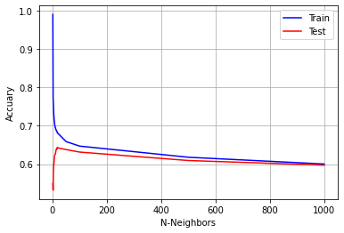

```python
train_accuracy = []
test_accuracy = []
neighbors = list(range(1 , 20)) + [50, 100, 500, 1000]

df = scale(final_df)

for n in neighbors:
    acc_train, acc_test = training('KNN', df, target, n, None, None, 0.2, False)
    train_accuracy.append(acc_train)
    test_accuracy.append(acc_test)

plt.plot(neighbors,train_accuracy,label='Train',color='b')
plt.plot(neighbors,test_accuracy,label='Test',color='r')
plt.grid()
plt.legend()
plt.xlabel('N-Neighbors')
plt.ylabel('Accuary')
plt.show()
```

**Q 2.4:**  
max_depth: The maximum depth of the tree. The deeper the tree, the more splits it has and it captures more information about the data.  
min_samples_split: The minimum number of samples required to split an internal node. When we increase this parameter, the tree becomes more constrained as it has to consider more samples at each node.

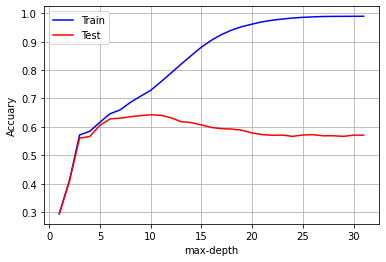

```python
train_accuracy = []
test_accuracy = []
max_depths = list(range(1, 32))
for d in max_depths:
    acc_train, acc_test = training('DT', df, target, None, d, 2, 0.2, False)
    train_accuracy.append(acc_train)
    test_accuracy.append(acc_test)

plt.plot(max_depths,train_accuracy,label='Train',color='b')
plt.plot(max_depths,test_accuracy,label='Test',color='r')
plt.grid()
plt.legend()
plt.xlabel('max-depth')
plt.ylabel('Accuary')
plt.show()
```

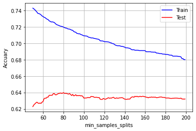

```python
train_accuracy = []
test_accuracy = []
min_samples_splits = list(range(50, 200))
for s in min_samples_splits:
    acc_train, acc_test = training('DT', final_df, target, None, None, s, 0.2, False)
    train_accuracy.append(acc_train)
    test_accuracy.append(acc_test)

plt.plot(min_samples_splits,train_accuracy,label='Train',color='b')
plt.plot(min_samples_splits,test_accuracy,label='Test',color='r')
plt.grid()
plt.legend()
plt.xlabel('min_samples_splits')
plt.ylabel('Accuary')
plt.show()
```

**Q 2.5:**

> - **overfitting:** When a model gets trained with so much data, it starts learning from the noise and inaccurate data entries in our data set. Then the model does not categorize the data correctly, because of too many details and noise.(the model is not general, has high accuracy in train data but low accuracy in test data)
> - **underfitting:** when we have fewer data to build an accurate model and also when we try to build a linear model with fewer non-linear data. (the model cannot capture the underlying trend of the data.)

> **KNN:**  
> We can clearly see that when number of neighbors is very small, the model overfits and when it goes high, the model underfits for both training and test data.

> **DecisionTree:**
> - max_depth: We see that our model overfits for large depth values. The tree perfectly predicts all of the train data, however, it fails to generalize the findings for new data.
> - min_samples_split: using large amounts, the model confuses and cannot learn enough about data thus underfitting happens.

**Q 2.6:**  
$ {Accuracy} = \frac {CorrectedDetected}{TotalSamples} $  
$ {Precision} = \frac {CorrectedDetectedClass}{AllDetectedClass(including wrong ones)} $  
$ {Recall} = \frac {CorrectedDetectedClass}{TotalClass} $  
$ {F1} = 2 * \frac {Precision * Recall}{Precision + Recall} $

```python
print("-----Results for K-Nearest-Neighbours-------")
training('KNN', df, target, 18, None, None, 0.2, True)
```

```
-----Results for K-Nearest-Neighbours-------
--> number of mismatched:  2031
--> evaluation metrics for test data:
              precision    recall  f1-score   support

 Alternative       0.51      0.40      0.45       946
   Classical       0.89      0.88      0.88       947
     Country       0.54      0.61      0.57       956
        Jazz       0.66      0.59      0.62       954
         Rap       0.72      0.76      0.74       947
        Rock       0.54      0.63      0.58       952

    accuracy                           0.64      5702
   macro avg       0.64      0.64      0.64      5702
weighted avg       0.64      0.64      0.64      5702

accuracy:  0.6438091897579796

--> evaluation metrics for train data:
              precision    recall  f1-score   support

 Alternative       0.56      0.45      0.50      3782
   Classical       0.91      0.88      0.89      3787
     Country       0.59      0.64      0.61      3823
        Jazz       0.71      0.66      0.68      3816
         Rap       0.75      0.78      0.76      3790
        Rock       0.59      0.67      0.63      3806

    accuracy                           0.68     22804
   macro avg       0.68      0.68      0.68     22804
weighted avg       0.68      0.68      0.68     22804

accuracy:  0.6808016137519733
```

```
(0.6808016137519733, 0.6438091897579796)
```

```python
print("-----Results for DecisionTree-------")
training('DT', df, target, None, 10, 80, 0.2, True)
```

```
-----Results for DecisionTree-------
--> number of mismatched:  2030
--> evaluation metrics for test data:
              precision    recall  f1-score   support

 Alternative       0.52      0.38      0.44       946
   Classical       0.88      0.87      0.88       947
     Country       0.59      0.57      0.58       956
        Jazz       0.65      0.57      0.61       954
         Rap       0.74      0.75      0.75       947
        Rock       0.51      0.72      0.59       952

    accuracy                           0.64      5702
   macro avg       0.65      0.64      0.64      5702
weighted avg       0.65      0.64      0.64      5702

accuracy:  0.6439845668186601

--> evaluation metrics for train data:
              precision    recall  f1-score   support

 Alternative       0.61      0.44      0.51      3782
   Classical       0.91      0.88      0.89      3787
     Country       0.64      0.63      0.63      3823
        Jazz       0.74      0.68      0.71      3816
         Rap       0.79      0.79      0.79      3790
        Rock       0.55      0.79      0.65      3806

    accuracy                           0.70     22804
   macro avg       0.71      0.70      0.70     22804
weighted avg       0.71      0.70      0.70     22804

accuracy:  0.6997456586563761
```

```
(0.6997456586563761, 0.6439845668186601)
```

**Q 2.7:**

- **Missing Values:** I decided to drop the rows which have missing value for _artist*name*, because the missing rate for this feature was low and also there is no other good ways to fill in the blanks for this column. In contrast, I fill missing values for _duration*ms* and *tempo* with mean of each column(dropping columns results in loss of data).
- **Label Encoding:** This is a crucial part of modeling. Without it, we either should ignore those columns or use one-hot instead. Ignoring would result in a seroius loss of data that would decrease model accuracy. Using one-hot has it's own problems. one-hotting all categorical columns would extremely increase the count of coulmns. This might result in providing too much data that might not be useful or even decieving. Here, I use binary encoding for *mode*, label encoding for *key* and _music*genre*, and dropping for _artist*name* and _track*name*.
- **Information_Gain:** After normalizing, I calculate information gain for each feature and delete those have less information gain.So I delete _duration*ms*, *mode*, *liveness*, *tempo* and *key*. It's important to note that you should choose the proper IG threshold. In our dataset, if we keep one of *mode* or _duration*ms*, the model will not work properly and accuracy decreases to less than 60%.
- **Normalization:** the scale and distribution of data maybe different for each feature. Differences in the scales across input features increase the difficulty of having a predicitve model.By normalization, all features are mapped to a same range. the normalization increases the accuracy by up to 10%.

## Phase 3: Ensemble Methods

**Q 3.1:**

```python
from sklearn.model_selection import GridSearchCV
from sklearn.ensemble import RandomForestClassifier
from sklearn.metrics import ConfusionMatrixDisplay

def forest(df, target, n_estimators=100, max_depth=5, min_samples_leaf=1, show=False):

    x_train, x_test, y_train, y_test = train_test_split(df, target, test_size=0.2, stratify=target, random_state=40)

    classifier = RandomForestClassifier(n_estimators=n_estimators, max_depth=max_depth, min_samples_leaf=min_samples_leaf, random_state=100)

    classifier.fit(x_train, y_train)
    test_pred = classifier.predict(x_test)
    train_pred = classifier.predict(x_train)
    res = pandas.concat([y_test.reset_index(drop=True), pandas.DataFrame(test_pred, columns=['predicted'])], axis=1)
    acc_train =  accuracy_score(y_train,train_pred)
    acc_test = accuracy_score(y_test,test_pred)
    if show:
        ConfusionMatrixDisplay.from_predictions(res['music_genre'], res['predicted'])
        print("--> number of mismatched: ", len(res[res['music_genre'] != res['predicted']]))
        print("--> evaluation metrics for test data: ")
        print(classification_report(y_test, test_pred))
        print("accuracy: ", acc_test)
        print("\n--> evaluation metrics for train data: ")
        print(classification_report(y_train, train_pred))
        print("accuracy: ", acc_train)
    return acc_train, acc_test
```

**Q 3.2:**

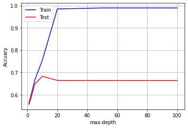

```python
train_accuracy = []
test_accuracy = []
max_depths = [1, 2, 5, 10, 20, 50, 100]
for d in max_depths:
    acc_train, acc_test = forest(df, target, 100, d, 1, False)
    train_accuracy.append(acc_train)
    test_accuracy.append(acc_test)

plt.plot(max_depths,train_accuracy,label='Train',color='b')
plt.plot(max_depths,test_accuracy,label='Test',color='r')
plt.grid()
plt.legend()
plt.xlabel('max-depth')
plt.ylabel('Accuary')
plt.show()
```

> **max_depth:** The maximum depth of the tree. The deeper the tree, the more splits it has and it captures more information about the data. for large depth values the model overfits and generality is lost.

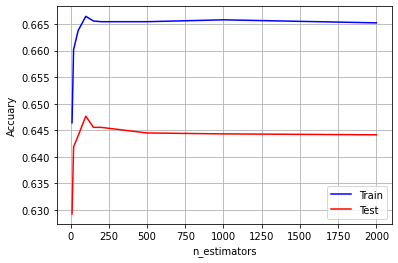

```python
train_accuracy = []
test_accuracy = []
n_estimators = [10, 20, 50, 100, 150, 200, 500, 1000, 2000]
for ne in n_estimators:
    acc_train, acc_test = forest(df, target, ne, 5, 1, False)
    train_accuracy.append(acc_train)
    test_accuracy.append(acc_test)

plt.plot(n_estimators,train_accuracy,label='Train',color='b')
plt.plot(n_estimators,test_accuracy,label='Test',color='r')
plt.grid()
plt.legend()
plt.xlabel('n_estimators')
plt.ylabel('Accuary')
plt.show()
```

> **n_estimators:** The number of trees in the forest. In general, more trees give us a better predictive model but more computational resources are consumed. It's good to note that I choose max_depth=5 and because of that we can see very small differences in accuracy of train and test data. If I let max_depth=default_value, then we can see a considarable difference between the accuracies.(accuracy of train data will be more than 95%)

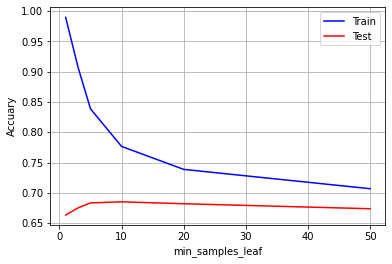

```python
train_accuracy = []
test_accuracy = []
min_samples_leaf = [1, 3, 5, 10, 20, 50]
for nl in min_samples_leaf:
    acc_train, acc_test = forest(df, target, 100, None, nl, False)
    train_accuracy.append(acc_train)
    test_accuracy.append(acc_test)

plt.plot(min_samples_leaf,train_accuracy,label='Train',color='b')
plt.plot(min_samples_leaf,test_accuracy,label='Test',color='r')
plt.grid()
plt.legend()
plt.xlabel('min_samples_leaf')
plt.ylabel('Accuary')
plt.show()
```

> **min_samples_leaf:** The minimum number of samples required to be at a leaf node. This parameter applies more constraints to the tree. For large values of min_samples_leaf the model cannot generalize and underfitting happens.

**Q 3.3, 3.4:**

```
--> number of mismatched:  1801
--> evaluation metrics for test data:
              precision    recall  f1-score   support

 Alternative       0.63      0.38      0.48       946
   Classical       0.91      0.87      0.89       947
     Country       0.66      0.59      0.62       956
        Jazz       0.68      0.69      0.68       954
         Rap       0.76      0.79      0.77       947
        Rock       0.53      0.78      0.63       952

    accuracy                           0.68      5702
   macro avg       0.69      0.68      0.68      5702
weighted avg       0.69      0.68      0.68      5702

accuracy:  0.6841459137144862

--> evaluation metrics for train data:
              precision    recall  f1-score   support

 Alternative       0.74      0.46      0.57      3782
   Classical       0.96      0.90      0.93      3787
     Country       0.72      0.64      0.68      3823
        Jazz       0.79      0.81      0.80      3816
         Rap       0.80      0.83      0.82      3790
        Rock       0.58      0.86      0.69      3806

    accuracy                           0.75     22804
   macro avg       0.76      0.75      0.75     22804
weighted avg       0.76      0.75      0.75     22804

accuracy:  0.7507454832485528
```

```
(0.7507454832485528, 0.6841459137144862)
```

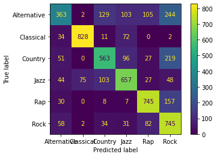

```python
forest(df, target, 100, 10, 2, True)
```